# ML Predictor of IBD Status from Microbiome Profiles

Paul B. Popa

ppopa93@gmail.com

2025-07-13

## Packages

```r
library(caret)
library(curatedMetagenomicData)
library(dplyr)
library(DT)
library(furrr)
library(ggplot2)
library(mia)
library(microbiome)
library(phyloseq)
library(plotly)
library(pROC)
library(PRROC)
library(purrr)
library(randomForest)
library(SummarizedExperiment)
library(table1)
library(tidymodels)
library(tidyverse)
library(TreeSummarizedExperiment)

# setup
options(DT.fillContainer = FALSE,
        DT.options = list(scrollY = "500px", scrollX = TRUE, scrollCollapse = FALSE, paging = FALSE)
)
```

## Retrieval of datasets from IBD-associated studies

```r
data("sampleMetadata")

# what diseases do we have available?
availablediseases <- pull(sampleMetadata, study_condition) %>%
  table() %>%
  sort(decreasing = TRUE)
availablediseases
```

```
#> .
#>                   control                       IBD                       T2D                       CRC
#>                     15121                      2088                       882                       701
#>                       IGT            premature_born                  melanoma                       CAD
#>                       563                       448                       315                       269
#>                      ACVD                   adenoma                       FMT                 cirrhosis
#>                       214                       209                       149                       132
#>                       STH                    otitis             schizophrenia              hypertension
#>                       108                       107                       106                        99
#>                        AS                        HF                       T1D           acute_diarrhoea
#>                        97                        95                        89                        56
#>          pre-hypertension                       CDI                    ME/CFS                  migraine
#>                        56                        53                        50                        49
#>                      STEC               fatty_liver                 psoriasis carcinoma_surgery_history
#>                        42                        41                        41                        40
#>                        AD            cephalosporins                        PD                    asthma
#>                        38                        36                        31                        24
#>             periodontitis                       SRP          peri-implantitis                        BD
#>                        24                        24                        23                        20
#>                 mucositis                bronchitis   TKI_dependent_diarrhoea            respiratoryinf
#>                        20                        18                        16                        13
#>        metabolic_syndrome                     donor            pyelonephritis infectiousgastroenteritis
#>                        10                         9                         6                         5
#>                      MDRB                     fever                 pneumonia               tonsillitis
#>                         5                         3                         3                         3
#>                     cough             pyelonefritis                   skininf                stomatitis
#>                         2                         2                         2                         2
#>                  cystitis             salmonellosis                    sepsis                   suspinf
#>                         1                         1                         1                         1
```

```r
# get list of IBD studies
list_ibd_studies <- filter(sampleMetadata, study_condition %in% "IBD") %>% pull(study_name) %>% unique()
list_ibd_studies
```

```
#> [1] "HallAB_2017"     "HMP_2019_ibdmdb" "IaniroG_2022"    "IjazUZ_2017"     "LiJ_2014"        "NielsenHB_2014"
#> [7] "VilaAV_2018"
```

```r
# create TSE object -- note that 'counts' is FALSE by default
se <- suppressMessages(
  sampleMetadata %>%
    filter(study_name %in% list_ibd_studies & study_condition %in% c("IBD", "control")) %>%
    returnSamples(dataType = "relative_abundance", counts = TRUE)
)
```

## Exploration

### Cohort characteristics

```r
table1::table1( ~ disease + disease_subtype + age + gender + study_name,
                data = colData(se))
```

|  | Overall (N=2887) |
| --- | --- |
| disease |  |
| healthy | 799 (27.7%) |
| IBD | 2051 (71.0%) |
| IBD;perianal_fistula | 37 (1.3%) |
| disease_subtype |  |
| CD | 1205 (41.7%) |
| UC | 860 (29.8%) |
| undetermined_colitis | 20 (0.7%) |
| Missing | 802 (27.8%) |
| age |  |
| Mean (SD) | 31.5 (18.6) |
| Median [Min, Max] | 29.0 [6.00, 76.0] |
| Missing | 657 (22.8%) |
| gender |  |
| female | 1362 (47.2%) |
| male | 1169 (40.5%) |
| Missing | 356 (12.3%) |
| study_name |  |
| HallAB_2017 | 259 (9.0%) |
| HMP_2019_ibdmdb | 1627 (56.4%) |
| IaniroG_2022 | 6 (0.2%) |
| IjazUZ_2017 | 94 (3.3%) |
| LiJ_2014 | 150 (5.2%) |
| NielsenHB_2014 | 396 (13.7%) |
| VilaAV_2018 | 355 (12.3%) |

### Convert TSE to phyloseq object

```r
# still a bug when working with counts...change name to 'counts' from 'relative_abundance' to be able to convert to phy using convertToPhyloseq
assayNames(se) <- "counts"
```

```r
phy <- mia::convertToPhyloseq(se, assay.type = "counts")
phy
```

```
#> phyloseq-class experiment-level object
#> otu_table()   OTU Table:         [ 940 taxa and 2887 samples ]
#> sample_data() Sample Data:       [ 2887 samples by 140 sample variables ]
#> tax_table()   Taxonomy Table:    [ 940 taxa by 7 taxonomic ranks ]
#> phy_tree()    Phylogenetic Tree: [ 940 tips and 939 internal nodes ]
```

Note that we have multiple samples per subject ID, i.e., our there is not a 1:1 mapping between sample and subject. This violates the assumption that each observation is independent. Additionally, subjects with more time points contribute disproportionately to alpha- and beta-diversity calculations, skewing measures of community richness and dissimilarity.

### Investigate pre-filtered data

```r
n_species <- tax_table(phy) %>%
  as("matrix") %>%                                # force a plain character matrix
  as_tibble() %>%                                 # now a tibble
  filter(!is.na(species), species != "") %>%      # drop NA or blank
  summarise(n = n()) %>%                          # count species
  pull(n)

n_species
```

```
#> [1] 935
```

So we have 940 TaxonID-level features, but 935 species-level features. Do we drop them?

```r
# turn tax_table from s4 obj to tibble
tax_df <- tax_table(phy) %>%
  as("matrix") %>%
  as_tibble(rownames = "TaxonID")

# turn sample_data from s4 obj to tibble
samp_df <- sample_data(phy) %>%
  as("matrix") %>%
  as_tibble(rownames = "SampleID")

# turn otu_table from s4 obj to tibble, with cols: TaxonID, Sample1, Sample2, …, SampleN
otu_df <- otu_table(phy) %>%
  as("matrix") %>%
  {if (!taxa_are_rows(phy)) t(.) else .} %>%
  as_tibble(rownames = "TaxonID")

# make otu_long have one row for every (TaxonID, SampleID) combo where count > 0
otu_long <- otu_df %>%
  pivot_longer(
    cols = -TaxonID,
    names_to  = "SampleID",
    values_to = "Count"
  )

# join otu_long to samp_df so that each row also carries its “study”
otu_with_study <- otu_long %>%
  dplyr::left_join(samp_df, by = "SampleID")

# collect unique set of studies where each TaxonID appears
tax_study <- otu_with_study %>%
  group_by(TaxonID) %>%
  summarize(
    # collapse unique study names into a comma‐separated string (or keep as list)
    Studies = paste0(study_name, collapse = "; "),
    # check if Count = 0 for all values for each TaxonID
    Counts_in_study = if (all(Count == 0)) {
      "All 0"
    } else {
      paste0(Count, collapse = "; ")
    }
  ) %>%
  ungroup()

na_species_with_study <- tax_table(phy) %>%
  as("matrix") %>%
  as_tibble(rownames = "TaxonID") %>%
  filter(is.na(species) | species == "") %>%
  dplyr::left_join(tax_study, by = "TaxonID")

na_species_with_study
```

```
#> # A tibble: 5 × 10
#>   TaxonID                                   superkingdom phylum class order family genus species Studies Counts_in_study
#>   <chr>                                     <chr>        <chr>  <chr> <chr> <chr>  <chr> <chr>   <chr>   <chr>
#> 1 k__Bacteria|p__Proteobacteria|c__Gammapr… Bacteria     Prote… Gamm… Ente… Enter… Ente… <NA>    HallAB… 0; 0; 0; 0; 0;…
#> 2 k__Bacteria|p__Proteobacteria|c__Gammapr… Bacteria     Prote… Gamm… Pseu… Pseud… Pseu… <NA>    HallAB… 0; 0; 0; 0; 0;…
#> 3 k__Bacteria|p__Firmicutes|c__Bacilli|o__… Bacteria     Firmi… Baci… Lact… Strep… Stre… <NA>    HallAB… 0; 0; 72896; 0…
#> 4 k__Bacteria|p__Actinobacteria|c__Corioba… <NA>         <NA>   <NA>  <NA>  <NA>   <NA>  <NA>    HallAB… 0; 0; 0; 0; 0;…
#> 5 k__Bacteria|p__Firmicutes|c__Bacilli|o__… Bacteria     Firmi… Baci… Baci… Bacil… Baci… <NA>    HallAB… 0; 0; 0; 0; 0;…
```

Even though the species is NA, we have counts for the TaxonID, so we should focus on the TaxonID.

## $\alpha$-diversity

Next, we want to better understand the control vs IBD data. We’ll look at $\alpha$-diversity and use two indices: Shannon and Simpson (see here for further info on Shannon and Simpson), to better understand how “diverse” the community is by combining info about richness (how many taxa) and evenness (how evenly their abundances are distributed).

Note that, since we used `counts = TRUE`, the counts are rounded, which has led to no singletons. This means we cannot estimate richness metrics such as Observed or Chao1. We have left “Observed” as a measure to display the warning that we in fact do not have singletons.

```r
# Extract richness from counts
#    a) remove sequencing noise and artifacts
#    b) reduces overestimation of diversity
#    c) improve comparability across samples
#    d) improve statistical validity (e.g., avoid unneccesarily inflating Type I error)

# estimate_richness provides per-sample diversity indices
alpha_raw <- estimate_richness(physeq =
  phy,
  measures = c("Shannon", "Simpson", "Observed")
)
```

```
#> Warning in estimate_richness(physeq = phy, measures = c("Shannon", "Simpson", : The data you have provided does not have
#> any singletons. This is highly suspicious. Results of richness
#> estimates (for example) are probably unreliable, or wrong, if you have already
#> trimmed low-abundance taxa from the data.
#>
#> We recommended that you find the un-trimmed data and retry.
```

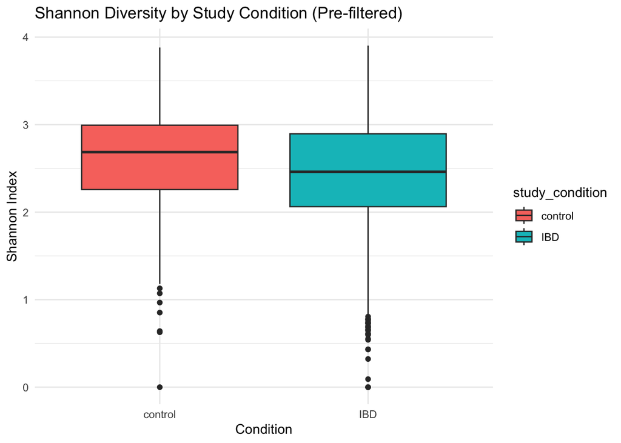

```r
# create df that combines metadata with richness estimates
div_df <- data.frame(
  sample = sample_names(phy),
  study_condition = sample_data(phy)$study_condition,
  Shannon = alpha_raw$Shannon,
  Simpson_D = alpha_raw$Simpson,
  InvSimpson = 1 - alpha_raw$Simpson      # (1 – D)
)

# boxplot Shannon by group
ggplot(div_df, aes(x = study_condition, y = Shannon, fill = study_condition)) +
  geom_boxplot() +
  theme_minimal() +
  labs(title = "Shannon Diversity by Study Condition (Pre-filtered)",
       x = "Condition", y = "Shannon Index")
```

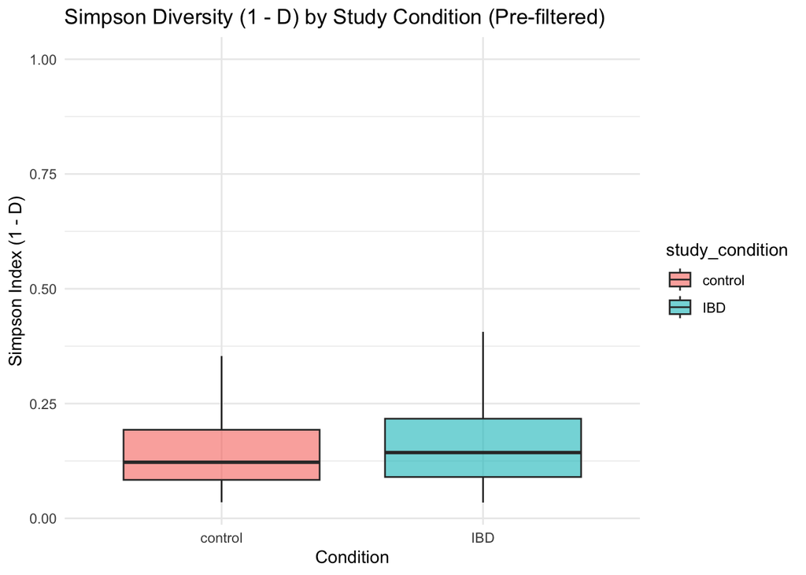

```r
# boxplot Simpson Diversity (1-D) by group
ggplot(div_df, aes(x = study_condition, y = InvSimpson, fill = study_condition)) +
  geom_boxplot(outlier.shape = NA, alpha = 0.6) +
  theme_minimal() +
  labs(title = "Simpson Diversity (1 - D) by Study Condition (Pre-filtered)",
       x = "Condition", y = "Simpson Index (1 - D)")
```

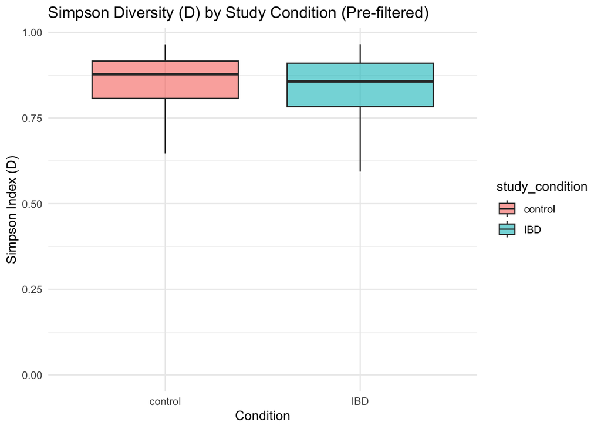

```r
# boxplot Simpson Diversity (D) by group
ggplot(div_df, aes(x = study_condition, y = Simpson_D, fill = study_condition)) +
  geom_boxplot(outlier.shape = NA, alpha = 0.6) +
  theme_minimal() +
  labs(title = "Simpson Diversity (D) by Study Condition (Pre-filtered)",
       x = "Condition", y = "Simpson Index (D)")
```

### Plot prevalence histogram

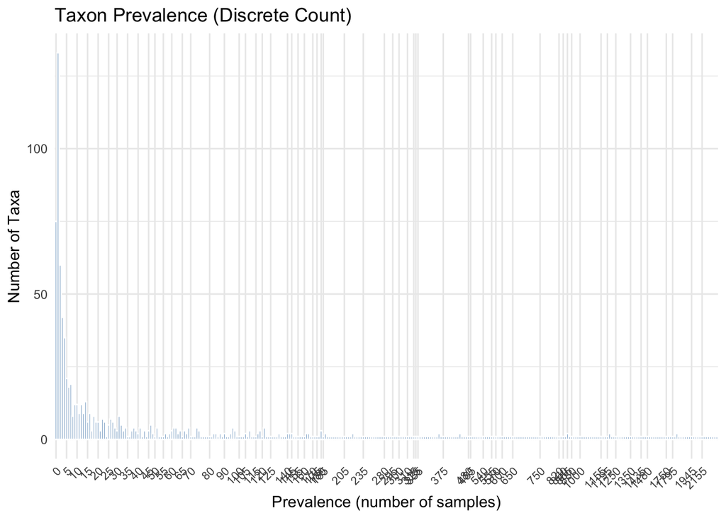

```r
# extract OTU table as a matrix
otu_mat <- as(otu_table(phy), "matrix")

# make sure rows = taxa, columns = samples. If phy has taxa as columns, transpose it
if (!taxa_are_rows(phy)) {
  otu_mat <- t(otu_mat)
}

# calculate prevalence: number of samples in which each taxon has count > 0
prevalence_df <- data.frame(
  Taxon      = rownames(otu_mat),
  prevalence = rowSums(otu_mat > 0)
) %>%
  mutate(prevalence_prop = prevalence / nsamples(phy)) %>%
  arrange(-prevalence)


# bar plot of prevalence
ggplot(prevalence_df, aes(x = factor(prevalence))) +
  geom_bar(fill = "steelblue", color = "white") +
  theme_minimal() +
  labs(
    title = "Taxon Prevalence (Discrete Count)",
    x     = "Prevalence (number of samples)",
    y     = "Number of Taxa"
  ) +
  scale_x_discrete(
    breaks = as.character(seq(0, max(prevalence_df$prevalence), by = 5))
  ) +
  theme(
    axis.text.x = element_text(angle = 45, hjust = 1, size = 8)
  )
```

#### View subset

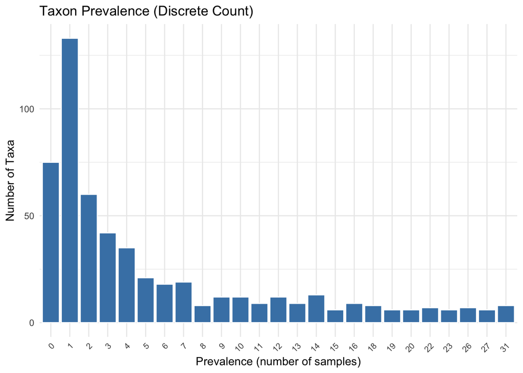

```r
# plot subset that have > 5 prevalence
ggplot(prevalence_df %>%
         group_by(prevalence) %>%
         filter(n() > 5) %>%
         ungroup(),
       aes(x = factor(prevalence))) +
  geom_bar(fill = "steelblue", color = "white") +
  theme_minimal() +
  labs(
    title = "Taxon Prevalence (Discrete Count)",
    x     = "Prevalence (number of samples)",
    y     = "Number of Taxa"
  ) +
  theme(
    axis.text.x = element_text(angle = 45, hjust = 1, size = 8)
  )
```

```r
# table view
DT::datatable(
  prevalence_df %>%
    filter(prevalence > 5) %>%
    arrange(-prevalence)
  )
```

|  | Taxon | prevalence | prevalence_prop |
| --- | --- | --- | --- |
| k__Bacteria\|p__Firmicutes\|c__Clostridia\|o__Clostridiales\|f__Ruminococcaceae\|g__Faecalibacterium\|s__Faecalibacterium_prausnitzii | k__Bacteria\|p__Firmicutes\|c__Clostridia\|o__Clostridiales\|f__Ruminococcaceae\|g__Faecalibacterium\|s__Faecalibacterium_prausnitzii | 2584 | 0.8950467613439557 |
| k__Bacteria\|p__Bacteroidetes\|c__Bacteroidia\|o__Bacteroidales\|f__Bacteroidaceae\|g__Bacteroides\|s__Bacteroides_vulgatus | k__Bacteria\|p__Bacteroidetes\|c__Bacteroidia\|o__Bacteroidales\|f__Bacteroidaceae\|g__Bacteroides\|s__Bacteroides_vulgatus | 2426 | 0.8403186698995497 |
| k__Bacteria\|p__Bacteroidetes\|c__Bacteroidia\|o__Bacteroidales\|f__Bacteroidaceae\|g__Bacteroides\|s__Bacteroides_uniformis | k__Bacteria\|p__Bacteroidetes\|c__Bacteroidia\|o__Bacteroidales\|f__Bacteroidaceae\|g__Bacteroides\|s__Bacteroides_uniformis | 2392 | 0.8285417388292345 |
| k__Bacteria\|p__Firmicutes\|c__Clostridia\|o__Clostridiales\|f__Ruminococcaceae\|g__Flavonifractor\|s__Flavonifractor_plautii | k__Bacteria\|p__Firmicutes\|c__Clostridia\|o__Clostridiales\|f__Ruminococcaceae\|g__Flavonifractor\|s__Flavonifractor_plautii | 2342 | 0.8112227225493592 |
| k__Bacteria\|p__Firmicutes\|c__Clostridia\|o__Clostridiales\|f__Lachnospiraceae\|g__Anaerostipes\|s__Anaerostipes_hadrus | k__Bacteria\|p__Firmicutes\|c__Clostridia\|o__Clostridiales\|f__Lachnospiraceae\|g__Anaerostipes\|s__Anaerostipes_hadrus | 2331 | 0.8074125389677866 |
| k__Bacteria\|p__Firmicutes\|c__Clostridia\|o__Clostridiales\|f__Lachnospiraceae\|g__Lachnospiraceae_unclassified\|s__Eubacterium_rectale | k__Bacteria\|p__Firmicutes\|c__Clostridia\|o__Clostridiales\|f__Lachnospiraceae\|g__Lachnospiraceae_unclassified\|s__Eubacterium_rectale | 2243 | 0.7769310703152061 |
| k__Bacteria\|p__Firmicutes\|c__Clostridia\|o__Clostridiales\|f__Lachnospiraceae\|g__Fusicatenibacter\|s__Fusicatenibacter_saccharivorans | k__Bacteria\|p__Firmicutes\|c__Clostridia\|o__Clostridiales\|f__Lachnospiraceae\|g__Fusicatenibacter\|s__Fusicatenibacter_saccharivorans | 2193 | 0.7596120540353308 |
| k__Bacteria\|p__Firmicutes\|c__Clostridia\|o__Clostridiales\|f__Lachnospiraceae\|g__Blautia\|s__Blautia_wexlerae | k__Bacteria\|p__Firmicutes\|c__Clostridia\|o__Clostridiales\|f__Lachnospiraceae\|g__Blautia\|s__Blautia_wexlerae | 2155 | 0.7464496016626255 |
| k__Bacteria\|p__Bacteroidetes\|c__Bacteroidia\|o__Bacteroidales\|f__Tannerellaceae\|g__Parabacteroides\|s__Parabacteroides_distasonis | k__Bacteria\|p__Bacteroidetes\|c__Bacteroidia\|o__Bacteroidales\|f__Tannerellaceae\|g__Parabacteroides\|s__Parabacteroides_distasonis | 2146 | 0.743332178732248 |
| k__Bacteria\|p__Bacteroidetes\|c__Bacteroidia\|o__Bacteroidales\|f__Bacteroidaceae\|g__Bacteroides\|s__Bacteroides_ovatus | k__Bacteria\|p__Bacteroidetes\|c__Bacteroidia\|o__Bacteroidales\|f__Bacteroidaceae\|g__Bacteroides\|s__Bacteroides_ovatus | 2136 | 0.7398683754762729 |

[output cut: 564 more lines]

### Filter low-abundance taxa

```r
# define grid of parameters
params <- expand.grid(
  min_reads            = c(1, 2, 3, 4, 5, 10, 50, 100, 200, 500, 1000, 2000),
  min_prevalence_prop  = c(0.001, 0.01, 0.05, 0.1, 0.2, 0.5), # number of samples
  stringsAsFactors     = FALSE
)

# for each row in params, filter taxa and record how many remain
keep_counts <- params %>%
  pmap_dfr(function(min_reads, min_prevalence_prop) {
    # keep taxa observed in >= min_reads in > min_prevalence_count
    phy_filt <- filter_taxa(
      phy,
      function(x) sum(x >= min_reads) > (min_prevalence_prop * length(x)),
      prune = TRUE
    )

    # create a one‐row tibble of results
    tibble(
      min_reads           = min_reads,
      min_prevalence_prop = min_prevalence_prop,
      n_taxa_kept         = ntaxa(phy_filt)
    )
  })

keep_counts %>% arrange(-n_taxa_kept)
```

```
#> # A tibble: 72 × 3
#>    min_reads min_prevalence_prop n_taxa_kept
#>        <dbl>               <dbl>       <int>
#>  1         1               0.001         672
#>  2         2               0.001         672
#>  3         3               0.001         672
#>  4         4               0.001         672
#>  5         5               0.001         672
#>  6        10               0.001         672
#>  7        50               0.001         672
#>  8       100               0.001         671
#>  9       200               0.001         669
#> 10       500               0.001         660
#> # ℹ 62 more rows
```

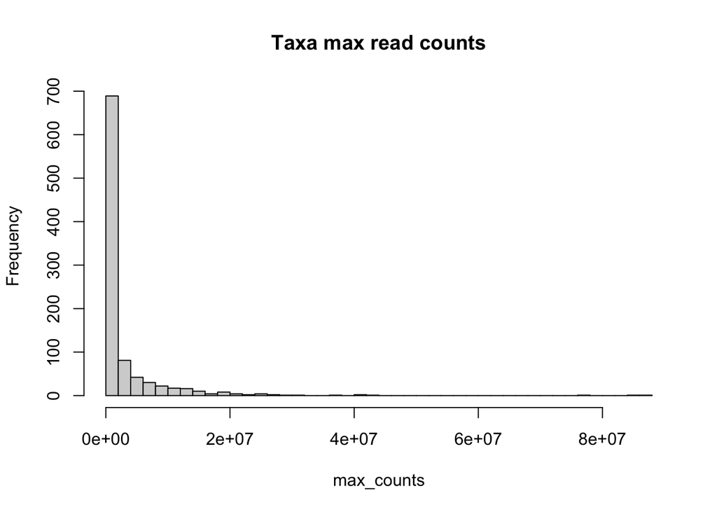

```r
max_counts <- apply(otu_table(phy), 1, max)
hist(max_counts, breaks = 50, main="Taxa max read counts")
```

This is hard to read — let’s “spread” the data, i.e., log-transform our data.

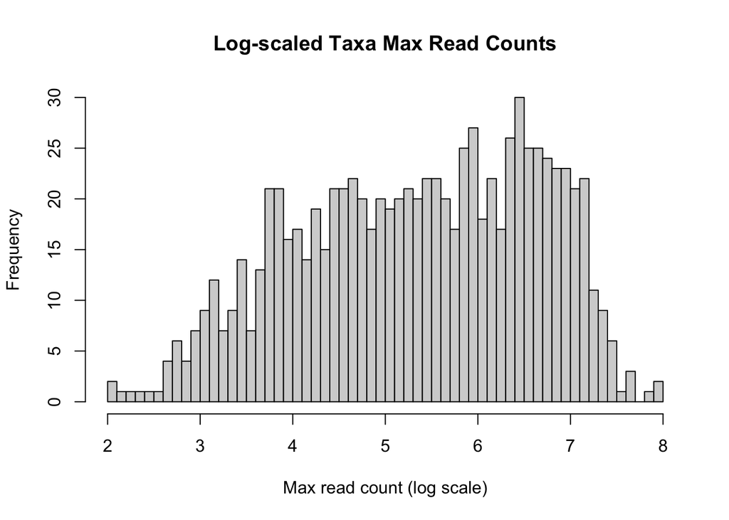

```r
# histogram plot of > 0 log-transformed counts
mc <- max_counts[max_counts > 0]
hist(log10(mc),
     breaks = 50,
     main   = "Log-scaled Taxa Max Read Counts",
     xlab   = "Max read count (log scale)"
     )
```

Note that the left tail (at around 2-3) implies “rare” taxa, while the right tail (at around > 6) implies highly dominant taxa.

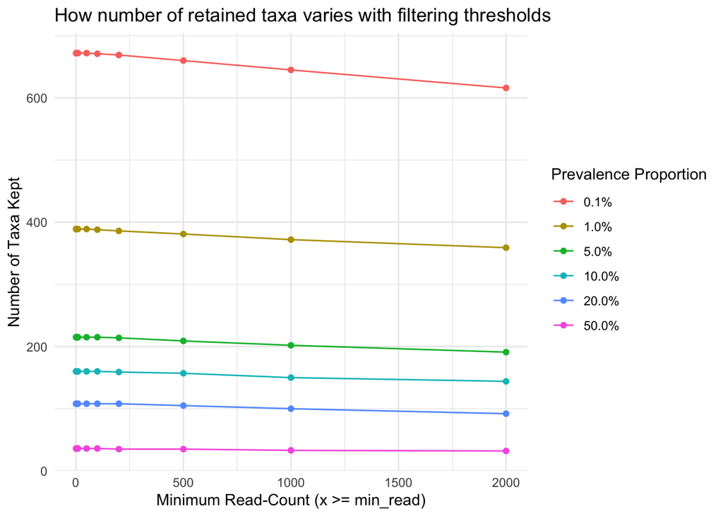

```r
# plot impact of filtering
ggplot(keep_counts, aes(x = min_reads, y = n_taxa_kept, color = factor(min_prevalence_prop))) +
  geom_line() +
  geom_point() +
  scale_color_discrete(
    name   = "Prevalence Proportion",         # legend title
    labels = function(x) percent(as.numeric(x), accuracy = 0.1)     # 0.05 to 5%
  ) +
  theme_minimal() +
  labs(
    title = "How number of retained taxa varies with filtering thresholds",
    x = "Minimum Read-Count (x >= min_read)",
    y = "Number of Taxa Kept"
  )
```

We need to balance noise removal and biological signal. Let’s investigate the phylum breakout to make sure we don’t lose phylums with > 1 prevalence.

```r
# Check phylum‐level breakdown of the M taxa kept to make sure don't filter out entire Phyla,
# pre-filter
tax_table_df <- as.data.frame(table(tax_table(phy)[, "phylum"])) %>%
  arrange(-Freq) %>%
  rename(
    phylum     = Var1,
    freq_orig  = Freq
  ) %>%
  mutate(
    Percent_phylum_orig = round((freq_orig / sum(freq_orig)) * 100, 1)
  )

str(tax_table_df)
```

```
#> 'data.frame':    20 obs. of  3 variables:
#>  $ phylum             : Factor w/ 20 levels "Actinobacteria",..: 12 16 3 1 13 10 18 2 17 11 ...
#>  $ freq_orig          : int  482 149 140 119 18 5 5 4 3 2 ...
#>  $ Percent_phylum_orig: num  51.4 15.9 14.9 12.7 1.9 0.5 0.5 0.4 0.3 0.2 ...
```

```r
tax_table_df
```

```
#>                         phylum freq_orig Percent_phylum_orig
#> 1                   Firmicutes       482                51.4
#> 2               Proteobacteria       149                15.9
#> 3                 Bacteroidota       140                14.9
#> 4               Actinobacteria       119                12.7
#> 5                 Fusobacteria        18                 1.9
#> 6                Euryarchaeota         5                 0.5
#> 7                Synergistetes         5                 0.5
#> 8                   Ascomycota         4                 0.4
#> 9                 Spirochaetes         3                 0.3
#> 10                      Evosea         2                 0.2
#> 11                 Tenericutes         2                 0.2
#> 12               Basidiomycota         1                 0.1
#> 13  Candidatus Melainabacteria         1                 0.1
#> 14 Candidatus Thermoplasmatota         1                 0.1
#> 15                  Chlamydiae         1                 0.1
#> 16                 Chloroflexi         1                 0.1
#> 17               Cyanobacteria         1                 0.1
#> 18               Lentisphaerae         1                 0.1
#> 19             Planctomycetota         1                 0.1
#> 20             Verrucomicrobia         1                 0.1
```

```r
# keep taxa with reads >= 100 in at least 1% of samples
phy_filtered <- filter_taxa(phy, function(x) sum(x >= 100) > (0.01 * length(x)), TRUE)
message("Kept ", ntaxa(phy_filtered), " out of ", ntaxa(phy), " taxa.\n")
```

```
#> Kept 388 out of 940 taxa.
```

```r
# check phylum‐level breakdown of the M taxa kept to make sure don't filter out entire Phyla,
# post-filter
tax_table_filtered_df <- as.data.frame(table(tax_table(phy_filtered)[, "phylum"])) %>%
  arrange(-Freq) %>%
  rename(
    phylum    = Var1,
    freq_sub  = Freq
  )

str(tax_table_filtered_df)
```

```
#> 'data.frame':    12 obs. of  2 variables:
#>  $ phylum  : Factor w/ 12 levels "Actinobacteria",..: 7 3 1 10 8 6 11 2 4 5 ...
#>  $ freq_sub: int  234 72 42 27 3 2 2 1 1 1 ...
```

```r
tax_table_filtered_df
```

```
#>                         phylum freq_sub
#> 1                   Firmicutes      234
#> 2                 Bacteroidota       72
#> 3               Actinobacteria       42
#> 4               Proteobacteria       27
#> 5                 Fusobacteria        3
#> 6                Euryarchaeota        2
#> 7                Synergistetes        2
#> 8                   Ascomycota        1
#> 9   Candidatus Melainabacteria        1
#> 10 Candidatus Thermoplasmatota        1
#> 11               Lentisphaerae        1
#> 12             Verrucomicrobia        1
```

```r
merged_tax_table_df <- merge(
  tax_table_df,
  tax_table_filtered_df,
  by    = "phylum",
  all.x = TRUE
  ) %>%
  mutate(
    # Compute percent of Freq_sub of original
    Percent_phylum_sub_of_orig = round((freq_sub / sum(freq_orig)) * 100, 1),
    Percent_freq_sub_of_orig   = round((freq_sub / freq_orig) * 100, 1)
  )


DT::datatable(merged_tax_table_df)
```

|  | phylum | freq_orig | Percent_phylum_orig | freq_sub | Percent_phylum_sub_of_orig | Percent_freq_sub_of_orig |
| --- | --- | --- | --- | --- | --- | --- |
| 1 | Actinobacteria | 119 | 12.7 | 42 | 4.5 | 35.3 |
| 2 | Ascomycota | 4 | 0.4 | 1 | 0.1 | 25 |
| 3 | Bacteroidota | 140 | 14.9 | 72 | 7.7 | 51.4 |
| 4 | Basidiomycota | 1 | 0.1 |  |  |  |
| 5 | Candidatus Melainabacteria | 1 | 0.1 | 1 | 0.1 | 100 |
| 6 | Candidatus Thermoplasmatota | 1 | 0.1 | 1 | 0.1 | 100 |
| 7 | Chlamydiae | 1 | 0.1 |  |  |  |
| 8 | Chloroflexi | 1 | 0.1 |  |  |  |
| 9 | Cyanobacteria | 1 | 0.1 |  |  |  |
| 10 | Euryarchaeota | 5 | 0.5 | 2 | 0.2 | 40 |

[output cut: 10 more lines]

We will choose 1% as our threshold, which seems like a good balance of signal vs noise while still retaining a broad range of taxa.

## Investigate filtered data

### How does “diversity” differ between IBD vs. control

$\alpha$-diversity often differs in disease vs. healthy (e.g., IBD typically has lower Shannon). We first visualize and then perform a formal test (i.e., Wilcoxon rank-sum test) to qualitatively and quantitatively compare the groups before jumping to our ML analysis.

```r
# Extract richness from the raw counts
#    a) remove sequencing noise and artifacts
#    b) reduces overestimation of diversity
#    c) improve comparability across samples
#    d) improve statistical validity (e.g., avoid unneccesarily inflating Type I error)
alpha_raw <- estimate_richness(
  phy_filtered,
  measures = c("Shannon", "Simpson")
)
alpha_raw
```

[output not shown]

[output cut: 447 more lines]

[output not shown]

```r
# Build a data.frame that combines metadata with these richness estimates.
div_df <- data.frame(
  sample          = rownames(alpha_raw),
  study_condition = sample_data(phy_filtered)$study_condition,
  Shannon         = alpha_raw$Shannon,
  Simpson_D       = alpha_raw$Simpson,       # raw D
  InvSimpson      = 1 - alpha_raw$Simpson    # (1 – D)
)
div_df
```

```
#>                 sample study_condition   Shannon Simpson_D InvSimpson
#> 1    SKST006_6_G102964             IBD 1.2522940 0.6372417 0.36275833
#> 2    SKST006_7_G102965             IBD 1.4010656 0.5467980 0.45320196
#> 3    SKST006_4_G102962             IBD 1.7122378 0.7658535 0.23414654
#> 4    SKST006_5_G102963             IBD 1.2635459 0.6865648 0.31343520
#> 5    SKST006_2_G102960             IBD 0.9780697 0.5907783 0.40922169
#> 6    SKST006_3_G102961             IBD 0.6130828 0.4220964 0.57790363
#> 7   SKST006_10_G102994         control 0.0000000 0.0000000 1.00000000
#> 8    SKST006_1_G102959             IBD 1.3779269 0.6894939 0.31050609
#> 9    SKST006_9_G103014             IBD 1.4712727 0.6384448 0.36155524
#> 10   SKST027_3_G102945             IBD 2.6546096 0.8849364 0.11506357
#> 11   SKST027_4_G102958             IBD 2.7693670 0.9025294 0.09747058
#> 12   SKST027_6_G102955             IBD 1.0200554 0.6072276 0.39277236
#> 13   SKST027_9_G102947             IBD 2.5510789 0.8891747 0.11082530
#> 14  SKST027_11_G102996             IBD 2.0612132 0.7799172 0.22008285
```

[output cut: 187 more lines]

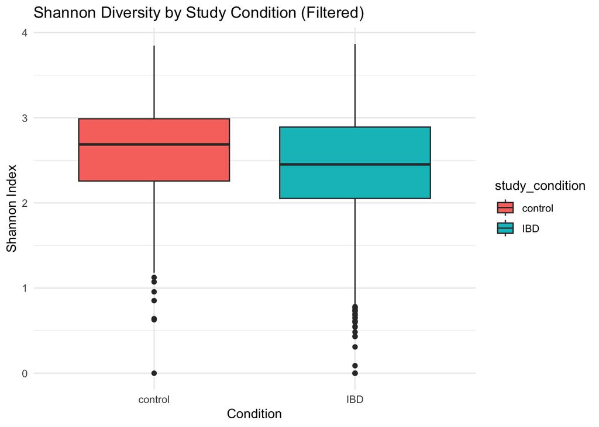

```r
# Boxplot Shannon by group
ggplot(div_df, aes(x = study_condition, y = Shannon, fill = study_condition)) +
  geom_boxplot() +
  theme_minimal() +
  labs(title = "Shannon Diversity by Study Condition (Filtered)",
       x = "Condition", y = "Shannon Index")
```

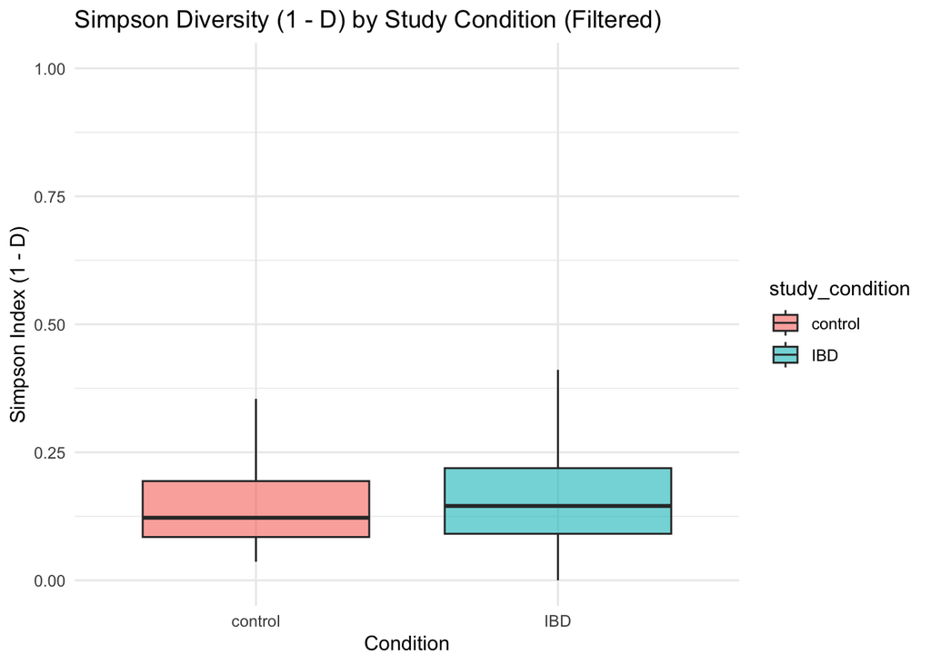

```r
# Boxplot Simpson Diversity (1-D) by group
ggplot(div_df, aes(x = study_condition, y = InvSimpson, fill = study_condition)) +
  geom_boxplot(outlier.shape = NA, alpha = 0.6) +
  theme_minimal() +
  labs(title = "Simpson Diversity (1 - D) by Study Condition (Filtered)",
       x = "Condition", y = "Simpson Index (1 - D)")
```

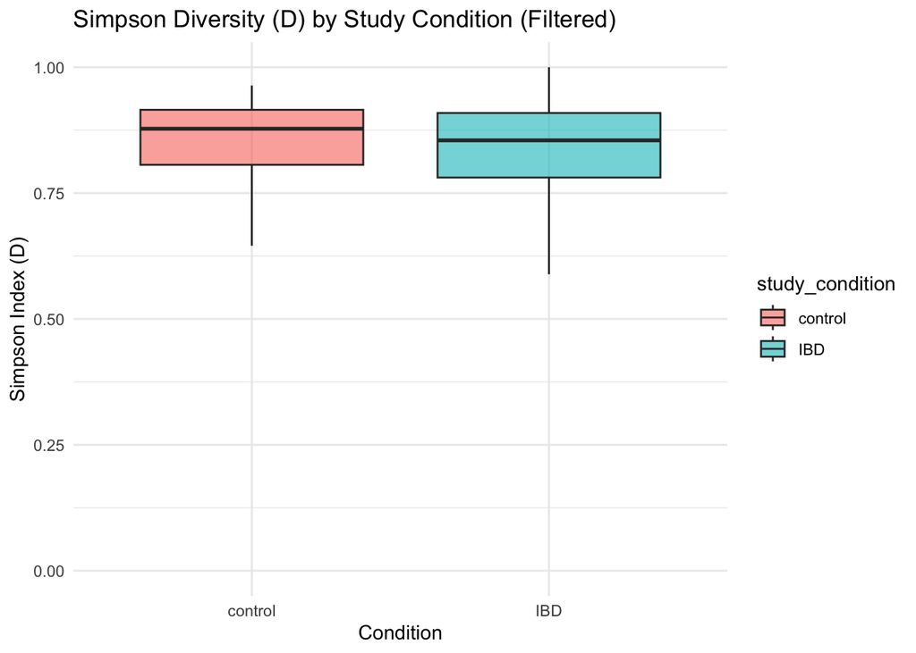

```r
# Boxplot Simpson Diversity (D) by group
ggplot(div_df, aes(x = study_condition, y = Simpson_D, fill = study_condition)) +
  geom_boxplot(outlier.shape = NA, alpha = 0.6) +
  theme_minimal() +
  labs(title = "Simpson Diversity (D) by Study Condition (Filtered)",
       x = "Condition", y = "Simpson Index (D)")
```

Shannon Index

- IBD Median Shannon Index $<$ control Median Shannon Index $\implies$ less microbial diversity than control
- Low-Shannon outliers in IBD: could reflect patients whose gut communities have lost many taxa (very few species or highly uneven communities), often interpreted as dysbiosis

Simpson Diversity (1 - D)

- Visually shows us that we have a relatively low diversity (i.e., 1 - D is closer to 0).

### Statistical test

We use the Wilcoxon-rank test.

$H_0$: The Shannon distributions in control and IBD come from the same population (i.e., no difference in median diversity).

$H_a$: The Shannon distributions in control and IBD differ (i.e., one group tends to have higher or lower Shannon).

```r
div_df %>%
  wilcox_test(Shannon ~ study_condition) %>%
  add_significance("p")
```

```
#> # A tibble: 1 × 8
#>   .y.     group1  group2    n1    n2 statistic        p p.signif
#>   <chr>   <chr>   <chr>  <int> <int>     <dbl>    <dbl> <chr>
#> 1 Shannon control IBD      799  2088   959496. 3.97e-10 ****
```

```r
div_df %>%
  # requires "coin" package
  wilcox_effsize(  # rank-biserial correlation
    Shannon ~ study_condition,
    alternative = "two.sided",
    conf.level  = 0.95,
    ci          = TRUE
  )
```

```
#> # A tibble: 1 × 9
#>   .y.     group1  group2 effsize    n1    n2 conf.low conf.high magnitude
#> * <chr>   <chr>   <chr>    <dbl> <int> <int>    <dbl>     <dbl> <ord>
#> 1 Shannon control IBD      0.116   799  2088     0.08      0.15 small
```

Given our extremely small p-value, i.e., $p\ll 0.05$, we reject the null hypothesis. There is statistically significant evidence that the Shannon index in controls is not drawn from the same distribution as in IBD.

This confirms that IBD patients in our cohort exhibit significantly reduced gut‐microbial $\alpha$‐diversity (Shannon index) compared to controls.

Rank-biserial correlation

- can be interpreted roughly like a Pearson r.
  - |r| $\approx$ 0.1 (small), $\approx$ 0.3 (medium), $\approx$ 0.5 (large)

effsize = 0.116 $\implies$ small rank-biserial correlation, indicating that control samples tend to have higher Shannon than IBD samples.

### CLR-Transform

Microbiome count tables are compositional — each sample’s taxa counts are only meaningful *relative* to one another and sum to an arbitrary total. The **centered log-ratio (CLR) transform** maps those compositions into real space so that standard multivariate methods (e.g. distance measures, classifiers) behave properly.

In the context of the Random Forest model, the CLR-transform removes sequencing-depth effects, stablizes variance, centers the features (so that each is on a comparable scale across samples), and respects compositional structure (ensuring measured distances between feature vectors reflect relative changes in taxa, not absolute counts).

```r
# clr-transform
phy_clr <- microbiome::transform(phy_filtered, "clr")
message("After CLR-transform: ntaxa = ", ntaxa(phy_clr), ", nsamples = ", nsamples(phy_clr))
```

```
#> After CLR-transform: ntaxa = 388, nsamples = 2887
```

## Train

### Define Random Forest Model

```r
train_rf <- function(phy_clr,
                     n_folds    = 5,
                     n_repeats  = 3,
                     seed       = 43,    # for reproducibility
                     trees      = 500) { # number of trees

  set.seed(seed)

  # extract feature matrix (samples by taxa) and metadata
  otu_mat  <- t(as(otu_table(phy_clr), "matrix"))
  meta_df  <- as(sample_data(phy_clr), "data.frame") %>%
    as_tibble(rownames = "SampleID") %>%
    mutate(
      Outcome   = factor(study_condition, levels = c("control","IBD")),
      SubjectID = as.character(subject_id)  # ensure character
    )

  # sanitize names so randomForest() doesn't yell
  colnames(otu_mat) <- make.names(colnames(otu_mat))

  data_all <- as_tibble(otu_mat, rownames = "SampleID") %>%
    dplyr::left_join(meta_df, by = "SampleID")

  message("Full data: ", nrow(data_all), " samples × ", ncol(otu_mat), " taxa; ",
          length(unique(data_all$SubjectID)), " subjects.")

  # grab feature cols
  feature_cols <- colnames(otu_mat)

  # pre-allocate lists for storing ROC objects & probabilities
  roc_list   <- list()   # pROC::roc objects
  probs_list <- list()   # numeric vectors of predicted probs
  labels_list <- list()  # test-set labels
  idx        <- 1        # running index


  # function to do one round of grouped k-fold CV
  one_repeat <- function(rep_id) {
    # shuffle and split unique subjects into folds
    subs      <- unique(data_all$SubjectID)
    subs      <- sample(subs)
    fold_ids  <- cut(seq_along(subs), breaks = n_folds, labels = FALSE)
    subject_folds <- split(subs, fold_ids)

    # for each fold, train, test, compute AUC
    purrr::map_dfr(seq_along(subject_folds), function(k) {

      test_subj <- subject_folds[[k]]

      train_df <- filter(data_all, !SubjectID %in% test_subj) %>%
                    dplyr::select(all_of(feature_cols), Outcome)
      test_df  <- filter(data_all,  SubjectID %in% test_subj) %>%
                    dplyr::select(all_of(feature_cols), Outcome)

      rf_mod <- randomForest(
        Outcome ~ .,
        data    = train_df,
        ntree   = trees
      )

      # predict probabilities for positive class "IBD"
      probs   <- predict(rf_mod, test_df, type = "prob")[, "IBD"]
      roc_obj <- roc(test_df$Outcome, probs, quiet = TRUE)

      # store for later
      probs_list[[idx]]    <<- probs
      roc_list[[idx]]      <<- roc_obj
      labels_list[[idx]]   <<- test_df$Outcome
      idx                  <<- idx + 1

      tibble(
        repeats    = rep_id,
        fold       = k,
        n_train    = nrow(train_df),
        n_test     = nrow(test_df),
        auc        = as.numeric(auc(roc_obj))
      )
    })
  }

  # run repeats in parallel
  cv_results <- future_map_dfr(seq_len(n_repeats), one_repeat, .options = furrr_options(seed = TRUE))

  # summarize
  summary_df <- cv_results %>%
    group_by(repeats) %>%
    summarize(
      mean_auc = mean(auc),
      sd_auc   = sd(auc),
      .groups  = "drop"
    ) %>%
    ungroup() %>%
    mutate(overall_mean = mean(mean_auc),
           overall_sd   = sd(mean_auc))

  list(
    cv_folds    = cv_results,   # df of AUCs per fold
    cv_summary  = summary_df,   # summary of AUCs
    probs_list  = probs_list,   # list of numeric vectors of probabilities
    roc_list    = roc_list,     # list of pROC::roc objects
    labels_list = labels_list   # list of test-set labels
  )
}
```

### Train + Test model

```r
# train the model
rf_workflow_fit <- train_rf(phy_clr)
```

```
#> Full data: 2887 samples × 388 taxa; 986 subjects.
```

## Results

### Prediction of IBD vs control

#### Plot ROC across folds

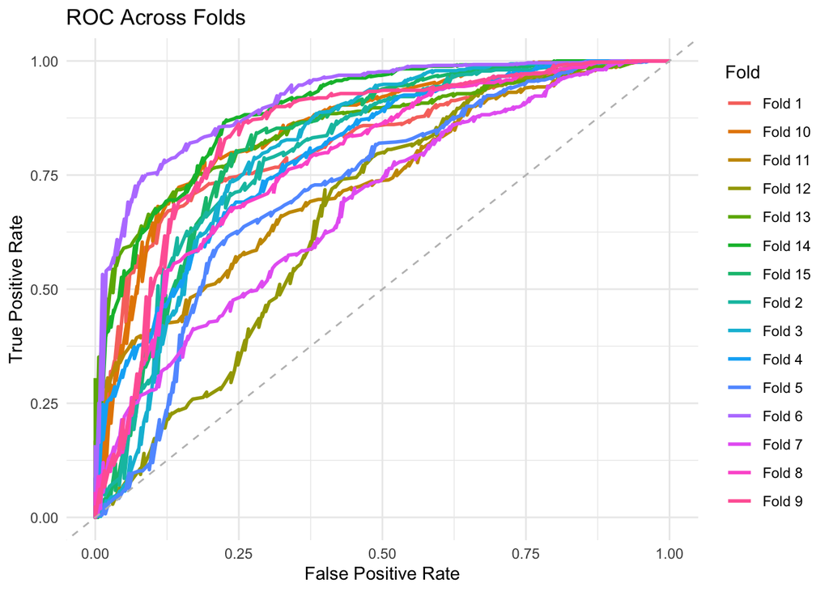

```r
# create ROC df
roc_df <- purrr::imap_dfr(rf_workflow_fit$roc_list, function(roc_obj, i) {
  data.frame(
    Fold       = paste0("Fold ", i),
    FPR        = 1 - roc_obj$specificities,
    TPR        = roc_obj$sensitivities
  )
})

# plot ROC
ggplot(roc_df, aes(x = FPR, y = TPR, color = Fold)) +
  geom_line(linewidth = 1) +
  geom_abline(linetype = "dashed", color = "gray") +
  labs(
    title = "ROC Across Folds",
    x     = "False Positive Rate",
    y     = "True Positive Rate"
  ) +
  theme_minimal()
```

We see the each fold’s ROC trade-off between TPR (sensitivity) and FPR (1-specificity). Looking across all folds helps us gauge the stability of our classifier. Given the wide spread signals, our classifier might depend on the training/test split. Let’s investigate.

#### Plot Average ROC with Confidence Bands

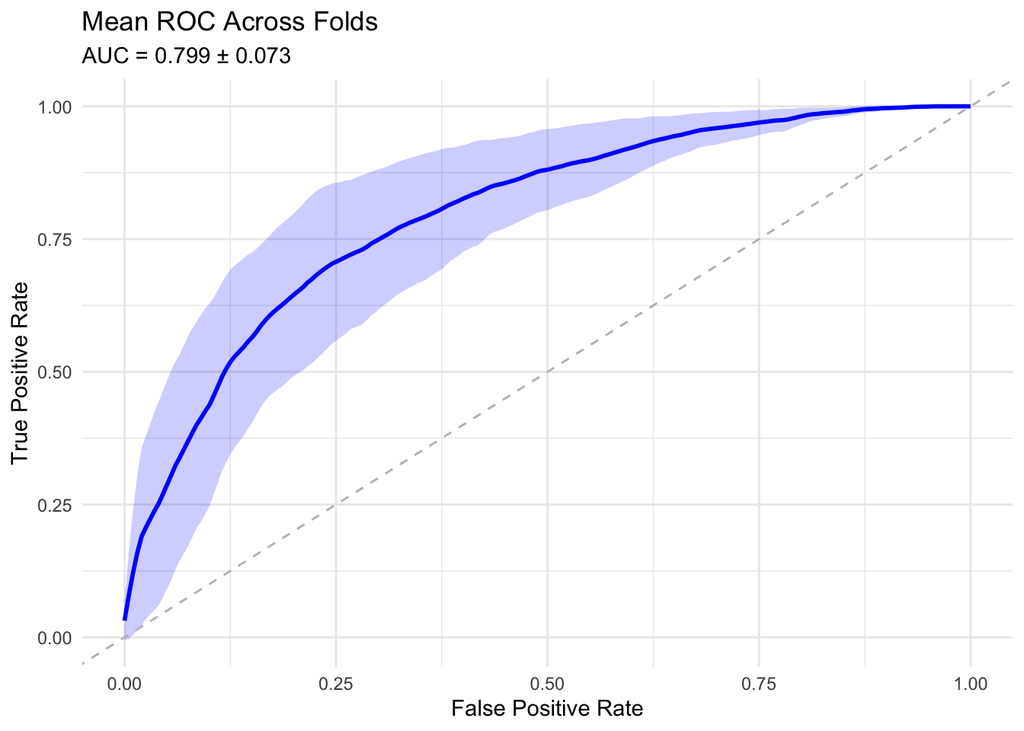

```r
# define grid
fpr_grid <- seq(0, 1, length.out = 200)

# create per-fold interpolated TPRs at correct grid
roc_df <- map_dfr(rf_workflow_fit$roc_list, ~{
  roc_obj <- .
  # interpolate TPR at desired FPRs via approx():
  fpr     <- 1 - roc_obj$specificities
  tpr     <- roc_obj$sensitivities
  interp  <- approx(x = fpr, y = tpr, xout = fpr_grid, ties = mean)
  tibble(FPR = fpr_grid, TPR = interp$y)
}, .id = "Fold")

# summarize mean and sd
summary_roc <- roc_df %>%
  group_by(FPR) %>%
  summarize(
    mean_TPR = mean(TPR, na.rm = TRUE),
    sd_TPR   = sd(TPR, na.rm = TRUE),
    .groups  = "drop"
  )

# plot mean ROC
ggplot(summary_roc, aes(x = FPR, y = mean_TPR)) +
  geom_ribbon(aes(ymin = mean_TPR - sd_TPR,
                  ymax = mean_TPR + sd_TPR),
              fill  = "blue", alpha = 0.2) +
  geom_line(color = "blue", size = 1) +
  geom_abline(linetype = "dashed", color = "gray") +
  labs(
    title    = "Mean ROC Across Folds",
    subtitle = sprintf("AUC = %.3f ± %.3f",
                       mean(sapply(rf_workflow_fit$roc_list, auc)),
                       sd  (sapply(rf_workflow_fit$roc_list, auc))),
    x        = "False Positive Rate",
    y        = "True Positive Rate"
  ) +
  theme_minimal()
```

#### Quantify AUC Variability

```r
# per‐fold AUC vector
aucs <- rf_workflow_fit$cv_folds$auc

# basic descriptors
mean_auc <- mean(aucs); sd_auc <- sd(aucs)
cat(sprintf("Mean AUC = %.3f ± %.3f\n", mean_auc, sd_auc))
```

```
#> Mean AUC = 0.799 ± 0.073
```

```r
# 95% CI via bootstrapping across folds
boot_ci <- boot::boot(aucs, statistic = function(u, i) mean(u[i]), R = 2000)
ci_vals <- boot::boot.ci(boot_ci, type = "perc")$percent[4:5]
cat(sprintf("Bootstrap 95%% CI: [%.3f, %.3f]\n", ci_vals[1], ci_vals[2]))
```

```
#> Bootstrap 95% CI: [0.763, 0.833]
```

#### Calibration Curves

Calibration shows how predicted probabilities map to observed frequencies.

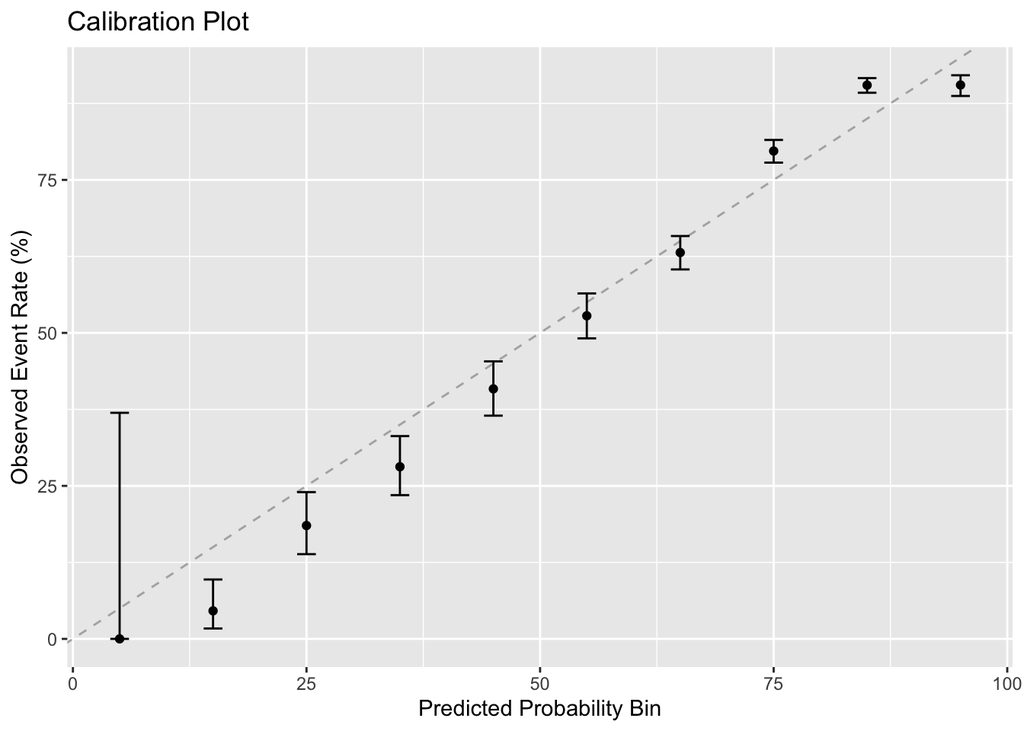

```r
# create calibration df
calib_df <- purrr::imap_dfr(
  rf_workflow_fit$probs_list,
  ~ tibble(
      Prob = .x,
      Obs  = rf_workflow_fit$labels_list[[.y]]
    )
)

# caret::calibration object
calib_obj <- caret::calibration(
  Obs ~ Prob,
  data   = calib_df,
  class  = "IBD",
  cuts   = 10  # number of bins
)

# plot calibration
ggplot(calib_obj, bwidth = 2, dwidth = 3) +
  labs(
    title = "Calibration Plot",
    x     = "Predicted Probability Bin",
    y     = "Observed Event Rate (%)"
  )
```

The diagonal reference line represents perfect calibration: predicted probability = observed frequency. Points above the line means the model’s predictions in that bin are too low (it underestimates risk), while points below the line means predictions are too high (it overestimates risk).

The width of the each error bar indicates how reliable the calibration is in that bin. Note that the wide error bars in the first bin is between 0-37%, which means that there may be very few IBD cases in that range, so we should be cautious in our interpretation.

However, looking at our bins, we actually see that there are *no* predictions in the first bin, which explains the very wide confidence bound since confidence intervals were forced on zero counts.

```r
calib_obj$data
```

```
#>    calibModelVar       bin   Percent     Lower     Upper Count midpoint
#> 1           Prob   [0,0.1]  0.000000  0.000000 36.941665     0        5
#> 2           Prob (0.1,0.2]  4.580153  1.699134  9.702458     6       15
#> 3           Prob (0.2,0.3] 18.518519 13.839956 23.983100    45       25
#> 4           Prob (0.3,0.4] 28.125000 23.487475 33.134896    99       35
#> 5           Prob (0.4,0.5] 40.853659 36.474839 45.343059   201       45
#> 6           Prob (0.5,0.6] 52.789116 49.106960 56.448805   388       55
#> 7           Prob (0.6,0.7] 63.128039 60.366941 65.826407   779       65
#> 8           Prob (0.7,0.8] 79.720280 77.819356 81.526941  1482       75
#> 9           Prob (0.8,0.9] 90.484140 89.238333 91.629918  2168       85
#> 10          Prob   (0.9,1] 90.503716 88.711493 92.096239  1096       95
```

Let’s further assess our model by checking how accurate our predictions are, on average. We will use the Brier score, which quantifies overall calibration, with lower values indicating better calibration.

#### Brier Score

```r
calib_df <- calib_df %>%
  mutate(
    OutcomeNum = as.integer(Obs == "IBD")  # 1 when Obs == "IBD", 0 otherwise
  )

# manual calculation
brier_score <- calib_df %>%
  summarise(Brier = mean((Prob - OutcomeNum)^2)) %>%
  pull(Brier)

brier_score
```

```
#> [1] 0.1532861
```

Our Brier score is closer to 0, which implies overall good calibration and discrimination. Let’s now compare how much better this is than baseline, i.e., calculate Brier Skill Score (BSS).

```r
# calculate IBD prevalence
prevalence <- mean(calib_df$OutcomeNum)
cat("IBD prevalence:", round(prevalence * 100, 1), "%\n")
```

```
#> IBD prevalence: 72.3 %
```

```r
# calculate BS_{ref}
BS_ref <- prevalence * (1 - prevalence)
cat("BS_ref:", BS_ref, "\n")
```

```
#> BS_ref: 0.200163
```

```r
# calculate BSS
BSS = 1 - (brier_score)/BS_ref
cat("BSS:", BSS)
```

```
#> BSS: 0.2341937
```

### Precision-Recall Curves

Let’s first quantify class imbalance.

```r
# flatten labels_list into one factor vector
all_labels <- unlist(rf_workflow_fit$labels_list, use.names = FALSE)

tab   <- table(all_labels)
pct   <- prop.table(tab) * 100

tab
```

```
#> all_labels
#> control     IBD
#>    2397    6264
```

```r
pct
```

```
#> all_labels
#>  control      IBD
#> 27.67579 72.32421
```

So we see that IBD dominates control (72% vs 28%).

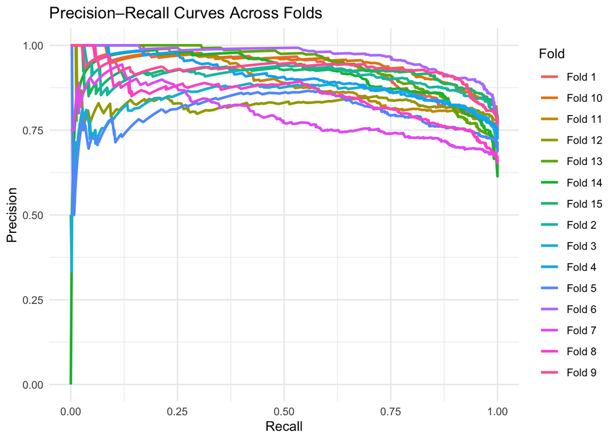

```r
# create PRROC objects per fold
pr_list <- imap(rf_workflow_fit$probs_list, function(probs, i) {
  labels <- rf_workflow_fit$labels_list[[i]]
  fg     <- probs[labels == "IBD"]       # scores for the positive class
  bg     <- probs[labels == "control"]   # scores for the negative class

  pr.curve(
    scores.class0 = fg,
    scores.class1 = bg,
    curve         = TRUE
  )
})

# create PR df
pr_df <- purrr::imap_dfr(pr_list, function(pr, i) {
  as.data.frame(pr$curve) %>%
    setNames(c("Recall", "Precision", "Threshold")) %>%
    mutate(Fold = paste0("Fold ", i))
})

# plot PR
ggplot(pr_df, aes(x = Recall, y = Precision, color = Fold)) +
  geom_line(size = 1) +
  labs(
    title = "Precision–Recall Curves Across Folds",
    x     = "Recall",
    y     = "Precision"
  ) +
  theme_minimal()
```

The clustering of curves near the top‐left indicates generally high precision even at moderate recall, while the spread between them reflects fold‐to‐fold variability in performance.

So how good is our model at capturing true positives, i.e., IBD prevalence?

### AUPRC

Recall that IBD prevalence is 72%, which means that a random classifier has AUPRC = 0.72. Area Under the Precision–Recall Curve (AUPRC) summarizes a model’s ability to retrieve true positives without overwhelming false positives by integrating precision over all recall levels. AUPRC’s baseline equals the positive‐class prevalence, making it especially informative in imbalanced settings.

```r
auprcs <- purrr::map_dbl(pr_list, ~ .x$auc.integral)

# Summary across folds
mean_auprc <- mean(auprcs)
sd_auprc   <- sd(auprcs)

cat(sprintf("Mean AUPRC = %.3f ± %.3f\n", mean_auprc, sd_auprc))
```

```
#> Mean AUPRC = 0.892 ± 0.054
```

Since our mean AURPC = 0.892 ± 0.054 $>$ 0.72, our model performs better than a random classifier.

Thus, a high AURPC alongside a low Brier score indicates both reliable probability estimates and strong discrimination.

### Confusion Matrix

```r
# get predictions and labels
results_df <- purrr::imap_dfr(
  rf_workflow_fit$probs_list,
  ~ tibble(
      Fold       = paste0("Fold ", .y),
      truth      = rf_workflow_fit$labels_list[[.y]],
      .pred_prob = .x
    )
) %>%
  # convert probabilities to class labels at 0.5 threshold
  mutate(.pred_class = factor(if_else(.pred_prob > 0.5, "IBD", "control"),
                              levels = levels(truth)))
# re-level so IBD comes first to make sure we calculate metrics for the correct "positive" class
results_df <- results_df %>%
  mutate(
    truth = fct_relevel(truth, "IBD", "control"),
    .pred_class = fct_relevel(.pred_class, "IBD", "control")
  )

# compute the confusion matrix
conf_mat_res <- results_df %>%
  yardstick::conf_mat(truth = truth, estimate = .pred_class)

# calculate metrics for binary classification

# Sensitivity
sens_res <- sens_vec(results_df$truth, results_df$.pred_class)
# Specificity
spec_res <- spec_vec(results_df$truth, results_df$.pred_class)
# Precision
ppv_res  <- precision_vec(results_df$truth, results_df$.pred_class)
# F1‐score
f1_res   <- f_meas_vec(results_df$truth, results_df$.pred_class)

data.frame(
  sens     = sens_res,
  spec     = spec_res,
  precision= ppv_res,
  F1        = f1_res
)
```

```
#>        sens      spec precision        F1
#> 1 0.9439655 0.3650396 0.7952925 0.8632747
```

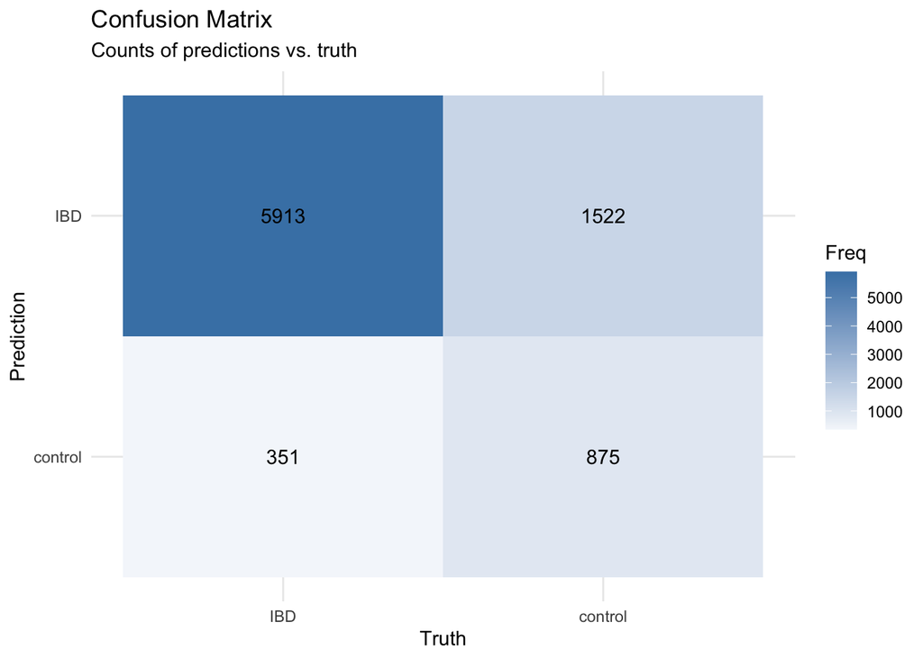

```r
# visualize the confusion matrix as heatmap
p <- autoplot(conf_mat_res, type = "heatmap")

# remove whatever scales (including 'fill') were already there to avoid warning
p$scales$scales <- list()

# add custom fill scale
  p +
    scale_fill_gradient2(low = "white", high = "steelblue") +
    labs(title = "Confusion Matrix",
         subtitle = "Counts of predictions vs. truth") +
    theme_minimal()
```

# Conclusion

We’ve classified subjects across several studies based on their gut microbiome samples, which may include repeat measurement samples, into two classes: IBD or control.

Our second step was to investigate the filtered data. We performed another $\alpha$-diversity analysis and ran the Wilcoxon-rank test, resulting in a rejection of the null hypothesis. That is, there is statistically significant evidence that the Shannon index in controls is not drawn from the same distribution as in IBD.

Our third step was to create, train, and test a Random Forest model. To account for repeated measurements across subjects, which violates the i.i.d. assumption underlying cross-validation, we incorporated repeated grouped k-fold CV, in our case, k = 5 with 3 repeats per fold. We fed the model CLR-transformed, which removes distortions of compositional bias, OTU abundances as features, which are now on an appropriate, comparable scale.

Our final step was to evaluate our model. We looked at ROC, AUC, calibration, precision-recall curves, AUPRC, and the confusion matrix and metrics. We determined that our model performs better than a random classifier, with a high AURPC alongside a low Brier score indicating both reliable probability estimates and strong discrimination.

Future work can look to improve the false positive rate for controls and compare different models for classification.

# Appendix: Definitions and Explanations

## $\alpha$-diversity

### Shannon Index

The Shannon index $H$ quantifies both richness (number of taxa) and evenness (relative abundance distribution) in a single value. It is defined as

$$H \;=\; -\sum_{i=1}^{S} p_i\,\ln(p_i)$$
where

- $S$ = total number of observed taxa (OTUs/ASVs) in the sample.
- $p_i$ = proportion of reads belonging to taxon $i$ (i.e. $p_i = \frac{n_i}{\sum_{j=1}^S n_j}$, where $n_i$ is the count of taxon $i$).

#### Key properties:

- $H$ increases as (1) the number of taxa $S$ increases, and (2) the abundances become more even.
- Minimum $H=0$ occurs when one taxon comprises 100% of the sample.
- Maximum $H = \ln(S)$ occurs when all $S$ taxa are equally abundant ($p_i = 1/S$ for all $i$).

### Simpson index

The **Simpson index** measures dominance (or conversely, diversity) by focusing on the probability of picking two reads from the same taxon. There are two common forms:

1. **Raw Simpson (D):**

   $$D \;=\; \sum_{i=1}^{S} p_i^2$$

   where, $D$ is the probability that two randomly drawn reads (with replacement) come from the same taxon.
   - $ D $
     - $D = 1$ if a single taxon dominates 100%.
     - $D=1/S$ if all $S$ taxa are equally abundant.
2. **Gini–Simpson or “Simpson’s Diversity” (1 – D):**

   $$1 - D \;=\; 1 \;-\; \sum_{i=1}^{S} p_i^2$$
   - $1 - D \in \left[0,\,1 - \frac{1}{S}\right]$
     - $1 - D = 0$ when one taxon dominates entirely.
     - $1 - D$ approaches 1 as the community becomes more even and richly diverse.

### Observed Richness

**Observed richness** simply counts how many taxa (OTUs/ASVs) are present in a sample:

$$S_{\text{obs}} \;=\; \sum_{i=1}^{S}
\mathbb{1}(n_i > 0)$$

where $\mathbb{1}(\cdot)$ is an indicator that equals 1 if taxon $i$ has at least one read. Thus, Observed richness measures raw taxon count without regard to abundance.

#### Chao1 Estimator

**Chao1** is a non‐parametric richness estimator that adjusts Observed richness for unseen (rare) taxa, using singletons (taxa with one read) and doubletons (two reads):

$$\widehat{S}_{\text{Chao1}} \;=\; S_{\text{obs}} \;+\;
\frac{f_1^2}{2\,f_2}$$
where

- $S_{\text{obs}}$ = number of observed taxa.
- $f_1$ = count of taxa observed exactly once.
- $f_2$ = count of taxa observed exactly twice.

When $f_2 = 0$ , one often uses a bias‐corrected form or sets $\widehat{S}_{\text{Chao1}} = S_{\text{obs}} + \frac{f_1(f_1 - 1)}{2}$

## CLR-transform

The centered log-ratio transform is a mapping of each composition $x_i$ (either a taxon count or proportion) from the simplex $S^d$ into the unconstrained (real) subspace $\{ y \in \mathbb{R}^d : \sum_{i=1}^d y_i = 0 \}$.

### Formula Summary

For a sample with taxa counts (or proportions) $(x_1, x_2, ..., x_d)$, define the geometric mean

$$g = \Bigl(\prod_{i=1}^d x_i\Bigr)^{1/d}$$

Then the CLR‐transformed vector is

$$\mathrm{clr}(x)_i \;=\; \log\!\bigl(\frac{x_i}{g(x)}\bigr)
\quad\text{for } i=1,\dots,d.$$

Because $\mathrm{clr}(x)_i = 0$, the transform removes the simplex constraint (i.e., the simplex constraint is that each sample’s taxa counts (or proportions) $(x_1, x_2, ..., x_d)$ satisfy:

1. Non-negativity: $x_i \geq 0 \;\; \forall i \in \{1,...,d\}$
2. Constant-sum (closure) constraint: $\sum_{i=1}^d x_i = 1$ ),

avoiding spurious correlations and misleading results that would arise from failing to meet the “unconstrained Euclidean space” assumption for PCA, Euclidean distances, and several classifiers.

## Wilcoxon rank-sum test

The Wilcoxon rank-sum test (also called the Mann–Whitney U test) is a non-parametric method for comparing two independent groups. It is an alternative to a two-sample t-test and does not assume normality, only that the two groups are independent and that the outcome is at least ordinal.

### Quick summary

1. Pool all observations from both groups and rank them from smallest to largest.
2. Sum the ranks within each group.
3. Compute the test statistic $U$.
4. Use either an exact table (small samples) or a normal approximation (large samples) to obtain a p-value under the null hypothesis that the two groups come from the same distribution.
   - Since we have moderate/large samples, we can calculate Z as

     $$Z \;=\; \frac{U \;-\; \mu_U}{\sigma_U}$$
     where
     $$\mu_U = \frac{n_1\,n_2}{2},
     \quad
     \sigma_U = \sqrt{\frac{n_1\,n_2\,(n_1 + n_2 + 1)}{12}}$$

### Formula summary

- **Ranks**: assign ranks to the pooled data.
- **Rank‐sum**:

  $$R_1 \;=\; \sum_{\text{all observations in group 1}} \text{(rank)}$$
- **U statistic** for group 1:

  $$U_1 \;=\; R_1 \;-\; \frac{n_1(n_1 + 1)}{2}$$
- **Mean and variance of U under** $H_0$:

  $$\mu_U = \frac{n_1\,n_2}{2},
  \quad
  \sigma_U = \sqrt{\frac{n_1\,n_2\,(n_1 + n_2 + 1)}{12}}$$
- Z**-score approximation**:

  $$Z = \frac{U - \mu_U}{\sigma_U}$$
- **Two‐sided p‐value** (for large samples):

  $$p = 2 \times P\bigl(|Z| \ge |Z_{\text{observed}}|\bigr)$$

## Brier score

A proper scoring rule that measures the accuracy of probabilistic predictions for binary outcomes by computing the mean squared difference between predicted probabilities and actual outcomes. A lower Brier score indicates better calibration and discrimination, with a perfect score of 0 and a worst score of 1.

### Formula summary

For **binary** events, the Brier score is defined as:

$$\text{Brier Score}
= \frac{1}{N} \sum_{i=1}^{N} (p_i - o_i)^2$$

where:

- $p_i$ is the predicted probability of the positive class for instance $i$,
- $o_i$ is the observed outcome (1 if the event occurred, 0 otherwise),
- $N$ is the number of forecasts

This can be thought of as the mean squared error of the predicted probabilities.

# References

1. Cao Q, Sun X, Rajesh K, Chalasani N, Gelow K, Katz B, Shah VH, Sanyal AJ, Smirnova E. Effects of Rare Microbiome Taxa Filtering on Statistical Analysis. Front Microbiol. 2021 Jan 12;11:607325. doi: 10.3389/fmicb.2020.607325. PMID: 33510727; PMCID: PMC7835481.